## M2.851 - Tipología y ciclo de vida de los datos

# PRA2 - Limpieza y análisis de datos

sguillen1 – Sandra Guillén Resina  
cperezceb – Carlos Pérez Cebrián

# Recursos

El desarrollo de la práctica se fundamenta con el material didáctico visto durante el curso:

- Calvo M., Subirats L., Pérez D. (2019). Introducción a la limpieza y análisis de los datos. Editorial UOC.
- Megan Squire (2015). Clean Data. Packt Publishing Ltd

El conjunto de datos utilizado está publicado en el repositorio Kaggle y accesible a través de la siguiente url:

- [Titanic: Machine Learning from Disaster.](https://www.kaggle.com/c/titanic)

# Objetivo y presentación del caso

La actividad se centra en el tratamiento de un dataset. En primer lugar, tendremos una fase de estudio previo para conocer cómo son nuestros datos, su estructura y su comportamiento. Una segunda fase de preparación, dónde aplicaremos la técnicas necesarias para la adecuación de los datos para la siguiente fase de análisis y, finalmente, y extraeremos conclusiones.

El dataset elegido tiene información sobre los pasajeros que viajaba abordo del Titanic. Como se detalla en el link de Kaggle, el dataset corresponde a una competición activa donde se debe desarrollar un modelo capaz de predecir la supervivencia de los pasajeros. Por ello, disponemos de tres datasets:

- train.csv que sería el conjunto de datos para diseñar nuestro algoritmo, el cual dispone de la variable *Survived* que identifica si sobrevivió o no al hundimiento.
- test.csv que sirve para validar la calidad de nuestro modelo.
- gender_submission.csv que identifica la supervivencia de cada uno de los pasajeros.

# Análisis inicial y exploración de los datos

Esta fase inicial tiene como objetivo conocer profundamente los datos tanto en su formato como contenido. Empezamos haciendo un breve revisión de los datasets; número de registros, tipos de datos, distribuciones de las variables..

Para ello cargamos los datos de los ficheros en la variable *data*. Primero leeremos el fichero train.csv

```r
dataTrain<-read.csv("./data/train.csv",header=T,sep=",")
attach(dataTrain)
dim(dataTrain)
```

```
## [1] 891  12
```

```r
head(dataTrain,3)
```

```
##   PassengerId Survived Pclass
## 1           1        0      3
## 2           2        1      1
## 3           3        1      3
##                                                  Name    Sex Age SibSp Parch
## 1                             Braund, Mr. Owen Harris   male  22     1     0
## 2 Cumings, Mrs. John Bradley (Florence Briggs Thayer) female  38     1     0
## 3                              Heikkinen, Miss. Laina female  26     0     0
##             Ticket    Fare Cabin Embarked
## 1        A/5 21171  7.2500              S
## 2         PC 17599 71.2833   C85        C
## 3 STON/O2. 3101282  7.9250              S
```

Completamos el dataset de Test con la variable *Survived*, por lo que, hacemos un merge con los otros ficheros, test y gender_submission. Verifición del tamaño de nuestros conjuntos de datos y sus variables.

```r
dataTest <-read.csv("./data/test.csv",header=T,sep=",")
dataReferencias <-read.csv("./data/gender_submission.csv",header=T,sep=",")
```

```
## [1] 418  11
```

```
##  [1] "PassengerId" "Pclass"      "Name"        "Sex"         "Age"
##  [6] "SibSp"       "Parch"       "Ticket"      "Fare"        "Cabin"
## [11] "Embarked"
```

```
## [1] "PassengerId" "Survived"
```

```
## [1] 418  11
```

```r
dataTest <- merge(dataTest, dataReferencias, by="PassengerId")
```

```
## [1] 418  12
```

```
##   PassengerId Pclass                             Name    Sex  Age SibSp Parch
## 1         892      3                 Kelly, Mr. James   male 34.5     0     0
## 2         893      3 Wilkes, Mrs. James (Ellen Needs) female 47.0     1     0
## 3         894      2        Myles, Mr. Thomas Francis   male 62.0     0     0
##   Ticket   Fare Cabin Embarked Survived
## 1 330911 7.8292              Q        0
## 2 363272 7.0000              S        1
## 3 240276 9.6875              Q        0
```

y finalmente unificamos nuestros dataset en un único dataframe, *data*

```r
data <- rbind(dataTrain, dataTest)
dim(data)
```

```
## [1] 1309   12
```

```r
head(data,3)
```

```
##   PassengerId Survived Pclass
## 1           1        0      3
## 2           2        1      1
## 3           3        1      3
##                                                  Name    Sex Age SibSp Parch
## 1                             Braund, Mr. Owen Harris   male  22     1     0
## 2 Cumings, Mrs. John Bradley (Florence Briggs Thayer) female  38     1     0
## 3                              Heikkinen, Miss. Laina female  26     0     0
##             Ticket    Fare Cabin Embarked
## 1        A/5 21171  7.2500              S
## 2         PC 17599 71.2833   C85        C
## 3 STON/O2. 3101282  7.9250              S
```

Verificamos la consistencia de nuestro dataset.

Comprobamos si existen duplicados, basándonos en el identificador del pasajero.

```r
#Obtener los valores repetidos para la variable PassengerId
duplicados <- unique(data[duplicated(data$PassengerId, fromLast=TRUE),])
table(duplicados$PassengerId)
```

```
## < table of extent 0 >
```

¿Qué variables componen nuestro dataset?

```
## 'data.frame':    1309 obs. of  12 variables:
##  $ PassengerId: int  1 2 3 4 5 6 7 8 9 10 ...
##  $ Survived   : int  0 1 1 1 0 0 0 0 1 1 ...
##  $ Pclass     : int  3 1 3 1 3 3 1 3 3 2 ...
##  $ Name       : chr  "Braund, Mr. Owen Harris" "Cumings, Mrs. John Bradley (Florence Briggs Thayer)" "Heikkinen, Miss. Laina" "Futrelle, Mrs. Jacques Heath (Lily May Peel)" ...
##  $ Sex        : chr  "male" "female" "female" "female" ...
##  $ Age        : num  22 38 26 35 35 NA 54 2 27 14 ...
##  $ SibSp      : int  1 1 0 1 0 0 0 3 0 1 ...
##  $ Parch      : int  0 0 0 0 0 0 0 1 2 0 ...
##  $ Ticket     : chr  "A/5 21171" "PC 17599" "STON/O2. 3101282" "113803" ...
##  $ Fare       : num  7.25 71.28 7.92 53.1 8.05 ...
##  $ Cabin      : chr  "" "C85" "" "C123" ...
##  $ Embarked   : chr  "S" "C" "S" "S" ...
```

Nuestra muestra contiene un total de 1309 registros y 12 variables distintas; 5 de tipo carácter, 5 de tipo integer y 2 numéricas.

Las variables del conjunto de datos son:

- **PassengerId**: Identificador del pasajero o tripulante.
- **Survived**: Varible que identifica si sobrevive o no al hundimiento. Valores posibles: “0-Fallece”, “1-Sobrevive”
- **Pclass**: hace referencia a la clase en la que viajaban los pasajeros (1ª, 2ª, 3ª).
- **Name**: Nombre del pasajero.
- **Sex**: Género del individuo. Valores posibles: male, female.
- **Age**: Edad del individuo.
- **SibSp**: Hermanos/as y conyuges a bordo.
- **Parch**: Padres e hijos.
- **Ticket**: Número de billete.
- **Fare**: Tarifa del billete.
- **Cabin**: Número de cabina.
- **Embarked**: Puerto de embarque. Valores posibles: “C = Cherbourg”, “Q = Queenstown” o “S = Southampton”

Veamos algunas métricas de estas variables, sus valores máximos, mínimos, medias…

```
##   PassengerId      Survived          Pclass          Name
##  Min.   :   1   Min.   :0.0000   Min.   :1.000   Length:1309
##  1st Qu.: 328   1st Qu.:0.0000   1st Qu.:2.000   Class :character
##  Median : 655   Median :0.0000   Median :3.000   Mode  :character
##  Mean   : 655   Mean   :0.3774   Mean   :2.295
##  3rd Qu.: 982   3rd Qu.:1.0000   3rd Qu.:3.000
##  Max.   :1309   Max.   :1.0000   Max.   :3.000
##
##      Sex                 Age            SibSp            Parch
##  Length:1309        Min.   : 0.17   Min.   :0.0000   Min.   :0.000
##  Class :character   1st Qu.:21.00   1st Qu.:0.0000   1st Qu.:0.000
##  Mode  :character   Median :28.00   Median :0.0000   Median :0.000
##                     Mean   :29.88   Mean   :0.4989   Mean   :0.385
##                     3rd Qu.:39.00   3rd Qu.:1.0000   3rd Qu.:0.000
##                     Max.   :80.00   Max.   :8.0000   Max.   :9.000
##                     NA's   :263
##     Ticket               Fare            Cabin             Embarked
##  Length:1309        Min.   :  0.000   Length:1309        Length:1309
##  Class :character   1st Qu.:  7.896   Class :character   Class :character
##  Mode  :character   Median : 14.454   Mode  :character   Mode  :character
##                     Mean   : 33.295
##                     3rd Qu.: 31.275
##                     Max.   :512.329
##                     NA's   :1
```

## Valores vacíos

Examinemos si hay valores missing. En caso de haberlos, habría que tomar decisiones para tratarlos adecuadamente y en aquellos casos que el porcentaje sea muy elevado deberemos descartar la variable. De igual manera, también eliminaríamos las observaciones con un número alto de valores vacíos.

```r
colSums(is.na(data))
```

```
## PassengerId    Survived      Pclass        Name         Sex         Age
##           0           0           0           0           0         263
##       SibSp       Parch      Ticket        Fare       Cabin    Embarked
##           0           0           0           1           0           0
```

```r
colSums(data=="")
```

```
## PassengerId    Survived      Pclass        Name         Sex         Age
##           0           0           0           0           0          NA
##       SibSp       Parch      Ticket        Fare       Cabin    Embarked
##           0           0           0          NA        1014           2
```

Observamos que debemos tratar las variables *Age*, *Fare*, *Cabin* y *Embarked*.

La variable *Cabin* la descartamos ya que tiene un porcentaje alto de datos vacios, de las 1309 observaciones disponibles 1014 no disponemos el datos.

```r
data$Cabin<-NULL
```

```r
data$Embarked[data$Embarked==""]<-"S"
```

**nota:** `tratar los valores de las variables _Fare_ y _Age_ por los valores próximos a sus vecinos`

## Valores atípicos

Examinemos las variables en busca de valores atípicos.

Nos ayudaremos de una representación gráfica como puede ser *boxplot*, cada variable será diferente pero consideraremos atípico aquellos valores que se encuentren a 1.5 veces de uno de los cuartiles.

### Pclass

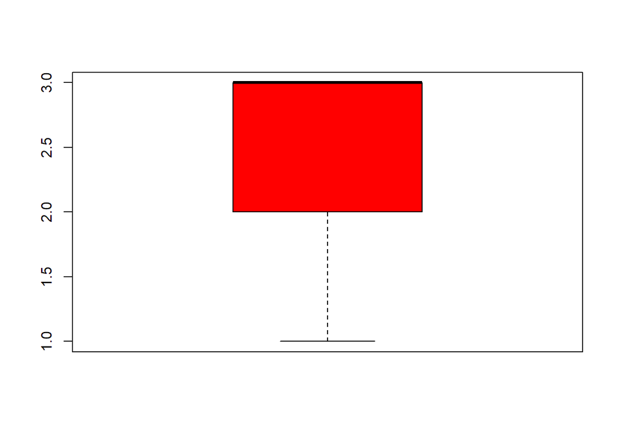

```r
boxplot(data$Pclass, col = "red")
```

### Age

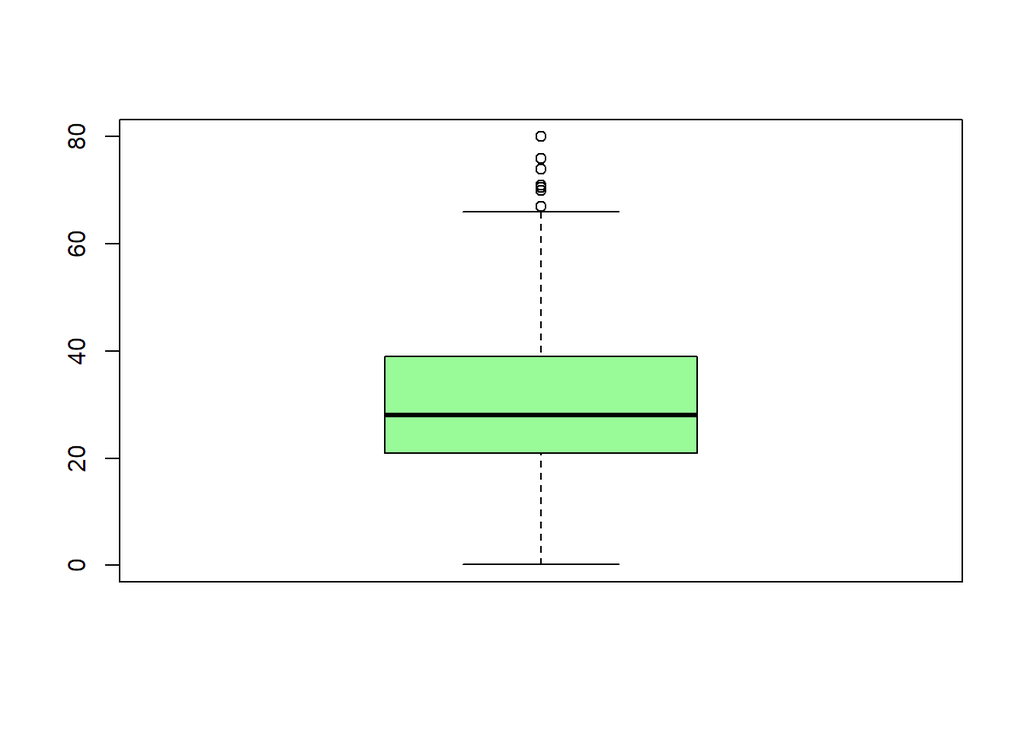

```r
boxplot(data$Age, col = "palegreen")
```

### SibSp

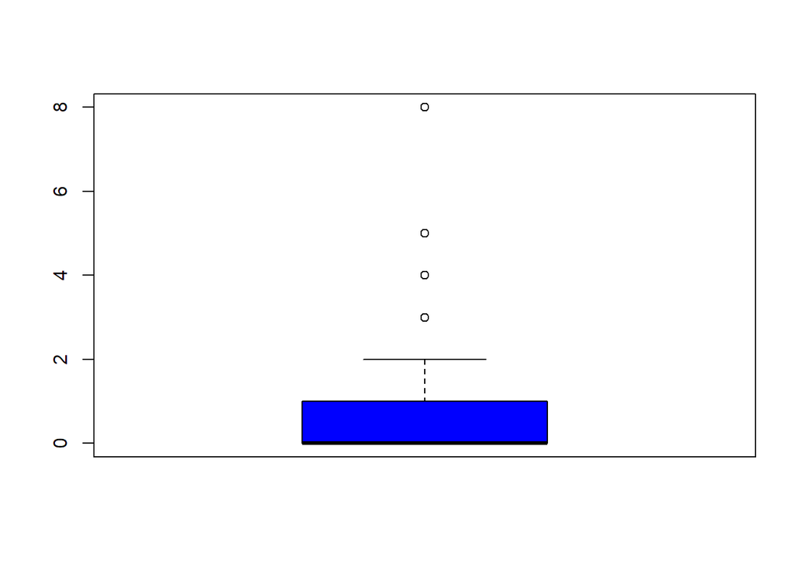

```r
boxplot(data$SibSp, col = "blue")
```

```r
 primer_cuartil<-quantile(data$SibSp, prob = 0.25, na.rm = TRUE)
 tercer_cuartil<-quantile(data$SibSp, prob = 0.75, na.rm = TRUE)
 rango_intercuartilico<-IQR(data$SibSp)

 menoresDe <- primer_cuartil - (1.5*rango_intercuartilico)
 mayoresDe <- tercer_cuartil + (1.5*rango_intercuartilico)

 sprintf("El rango de valores que limitan el rango es: %f - %f", menoresDe, mayoresDe )
```

```
## [1] "El rango de valores que limitan el rango es: -1.500000 - 2.500000"
```

### Parch

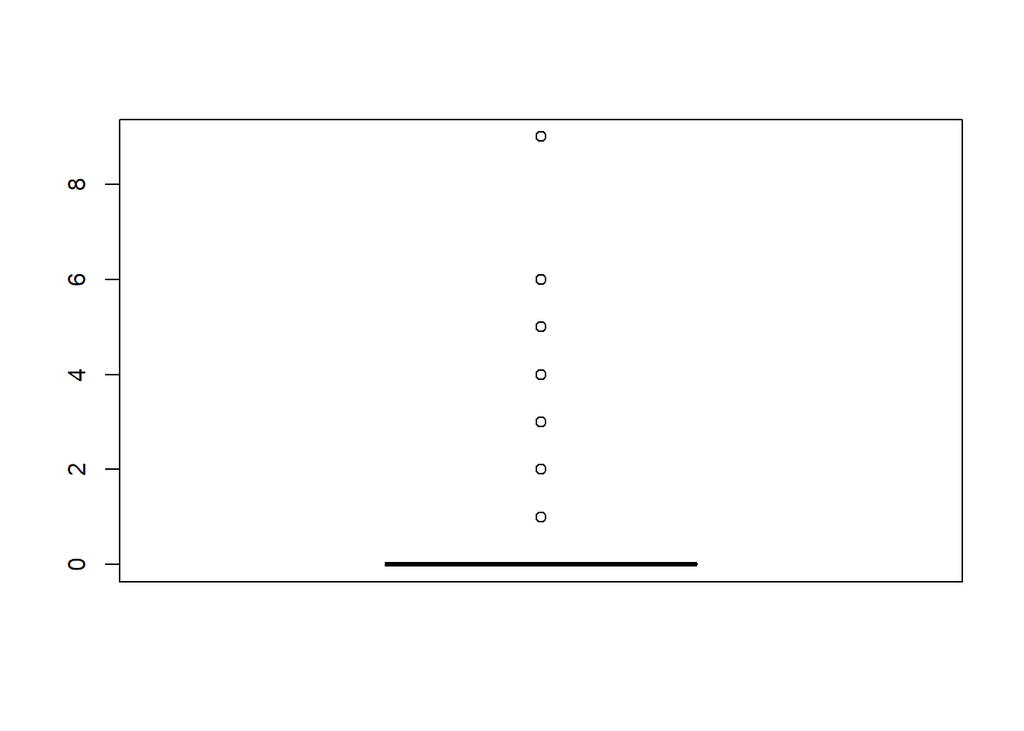

```r
boxplot(data$Parch, col = "orange")
```

### Fare

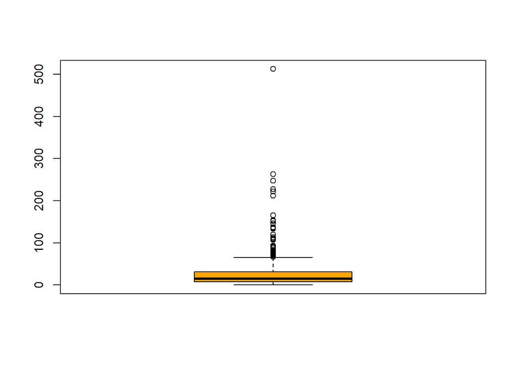

```r
boxplot(data$Fare, col = "orange")
```

## Normalización, categorización y selección de variables

Factorizamos la variable *Sex* y la variable *Embarked*

```r
data$Sex <- as.factor(data$Sex)
data$Embarked <- as.factor(data$Embarked)
```

Categorizamos las variables numéricas, *Age* y *Fare*, en rangos/tramos de valores

**nota:** `igual debemos normalizarlos: data$Age<-(data$Age - min(data$Age)) / (max(data$Age) - min(data$Age))`

```r
data["Age"] <- cut(data$Age, breaks = c(0,20,40,60,80,100), labels = c("0-19", "20-39","40-59","60-79",">79"))
data$Age <- as.factor(data$Age)

data["Fare"] <- cut(data$Fare, breaks = c(0,10,20,30,40,50,60,70,100), labels = c("0-9", "10-19", "20-29", "30-39","40-49","50-59","60-69","70-79"))
data$Fare <- as.factor(data$Fare)
```

Transformamos los valores de la varible *Survived* para que sea “S” para los supervivientes y “N” para identificar los no supervivientes

```r
data$Survived[data$Survived == 1]<-'S'
data$Survived[data$Survived == 0]<-'N'
data$Survived <- as.factor(data$Survived)
```

A priori, podemos descartar las variables *Ticket*, *Name* y *PassengerId* ya que no van a formar parte de nuestros análisis y, de esta forma, utilizaremos un conjunto de datos menor.

```r
data$Name<-NULL
data$Ticket<-NULL
data$PassengerId<-NULL
```

Tras las transformaciones realizadas, el conjunto de datos presenta el siguiente aspecto:

```
## 'data.frame':    1309 obs. of  8 variables:
##  $ Survived: Factor w/ 2 levels "N","S": 1 2 2 2 1 1 1 1 2 2 ...
##  $ Pclass  : int  3 1 3 1 3 3 1 3 3 2 ...
##  $ Sex     : Factor w/ 2 levels "female","male": 2 1 1 1 2 2 2 2 1 1 ...
##  $ Age     : Factor w/ 5 levels "0-19","20-39",..: 2 2 2 2 2 NA 3 1 2 1 ...
##  $ SibSp   : int  1 1 0 1 0 0 0 3 0 1 ...
##  $ Parch   : int  0 0 0 0 0 0 0 1 2 0 ...
##  $ Fare    : Factor w/ 8 levels "0-9","10-19",..: 1 8 1 6 1 1 6 3 2 4 ...
##  $ Embarked: Factor w/ 3 levels "C","Q","S": 3 1 3 3 3 2 3 3 3 1 ...
```

## Distribución de las variables

Utilizaremos gráficos para la representación de los datos y así aportar un mayor enriquecimiento del conocimiento sobre ellos.

Requeriremos de los paquetes ggplot2, gridExtra y grid de R.

Representamos la distribución de las variables y donde se ve reflejado las afirmaciones extraídas sobre los datos anteriores.

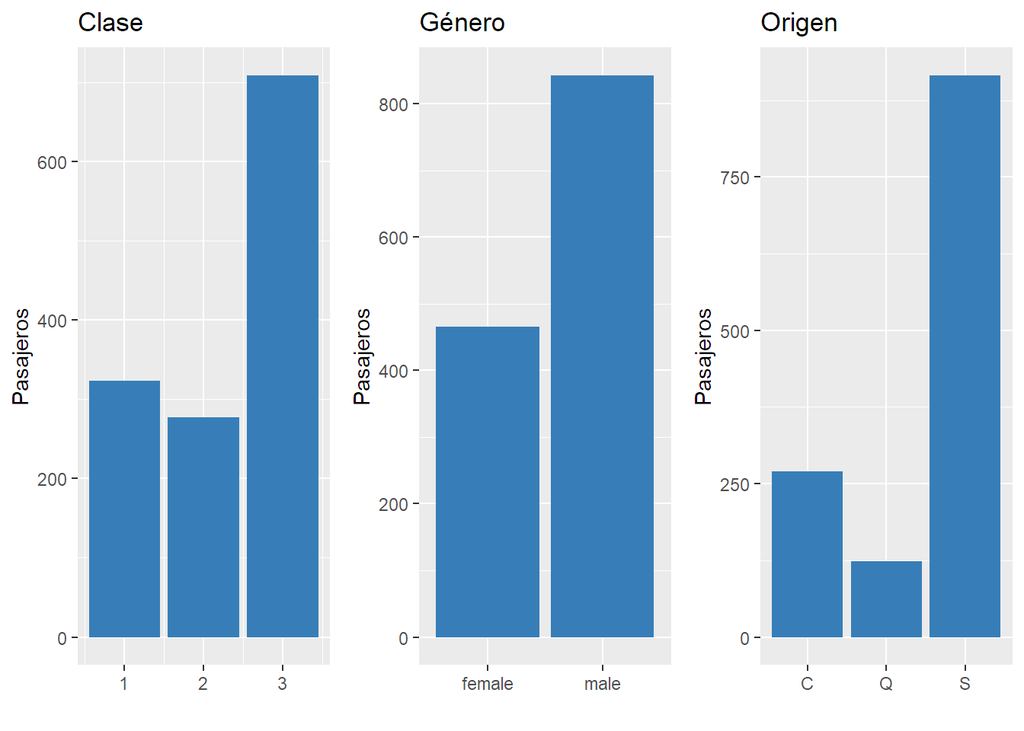

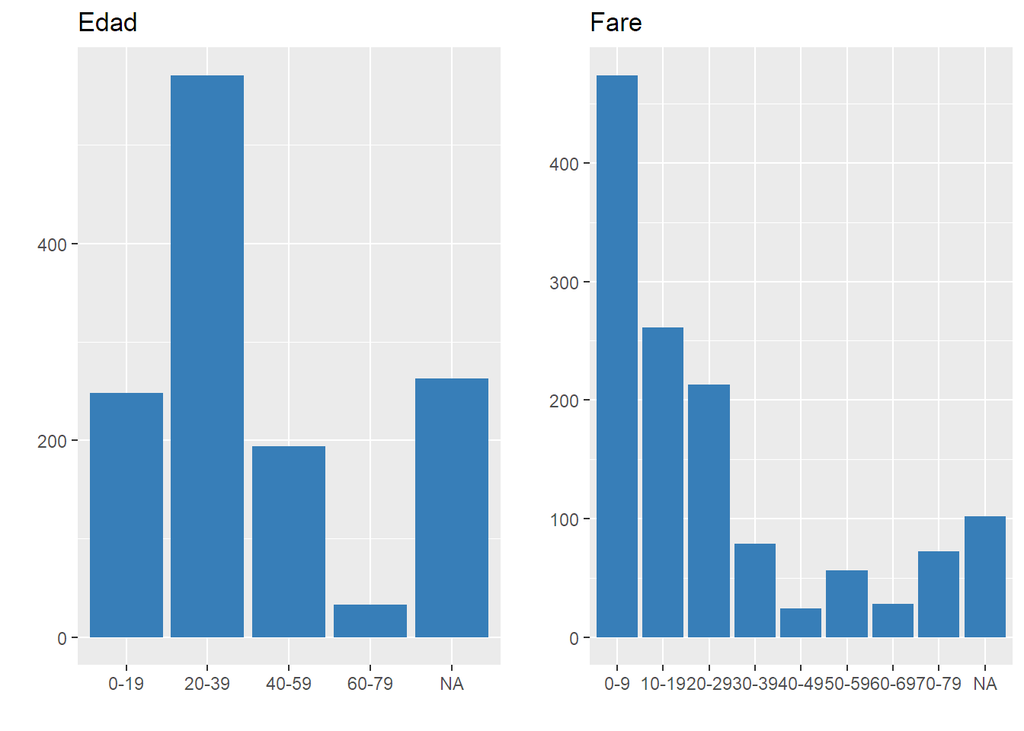

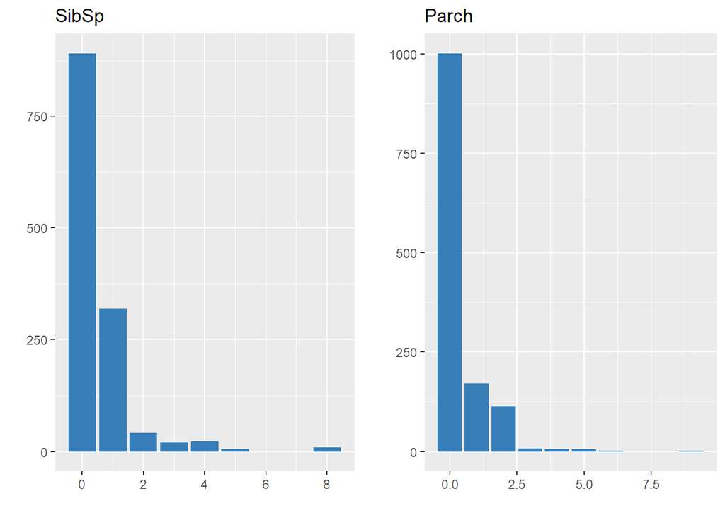

A continuación, se muestra la distribución de la varible supervivencia, que además, nos interesa describir su relación con el resto de variables.

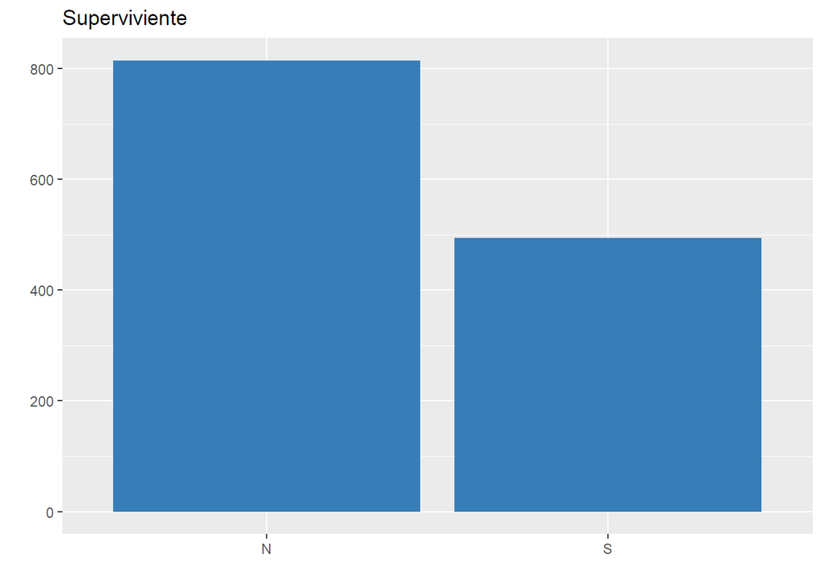

```r
 ggplot(data,aes(Survived))+geom_bar(fill = "#377EB8") +labs(x="", y="")+ggtitle("Superviviente")
```

Por otro lado, para obtener los datos que estamos graficando utilizaremos el comando table para dos variables que nos proporciona una tabla de contingencia.

## Relación con la variable supervivencia

**nota::** `revisar los datos porque cambian al aplicar las transformaciones de valores vacíos...`

De estos gráficos obtenemos información muy valiosa que complementamos con las tablas de contingencia (listadas abajo).

Por un lado, sobrevivieron un mayor número de mujeres que de hombre, hombres: 109 y mujeres 233 y el porcentaje de supervivencia en el caso de las mujeres se situa entorno al 74%, mientras que la de los hombres es del 18.89%, por lo tanto, la tasa de muerte en hombres es muchísimo mayor 81%.

En cuanto a la clase en la que viajaban, los pasajeros que viajaban en primera clase fueron los únicos que el porcentaje de supervivencia era mayor que el de mortalidad. El 62,96% de los viajeros de primera clase sobrevivió, el 47,3% de los que viajaban en segunda clase mientras que de los viajeros de tercera solo sobrevivieron un 24,23%.

Aunque el grupo de menores es pequeño son los que mayor porcentaje de supervivencia presentan, manteniendose este comportamiento en cada una de la clases.

### Pclass

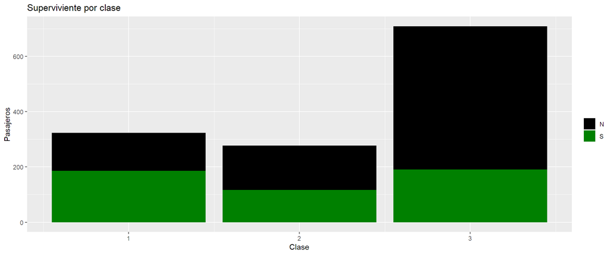

```r
ggplot(data,aes(Pclass,fill=Survived))+geom_bar() +labs(x="Clase", y="Pasajeros")+ guides(fill=guide_legend(title=""))+ scale_fill_manual(values=c("black","#008000"))+ggtitle("Superviviente por clase")
```

```r
tablaClass <- table(Pclass,Survived)
tablaClass
```

```
##       Survived
## Pclass   0   1
##      1  80 136
##      2  97  87
##      3 372 119
```

```r
prop.table(tablaClass, margin = 1)
```

```
##       Survived
## Pclass         0         1
##      1 0.3703704 0.6296296
##      2 0.5271739 0.4728261
##      3 0.7576375 0.2423625
```

### Age

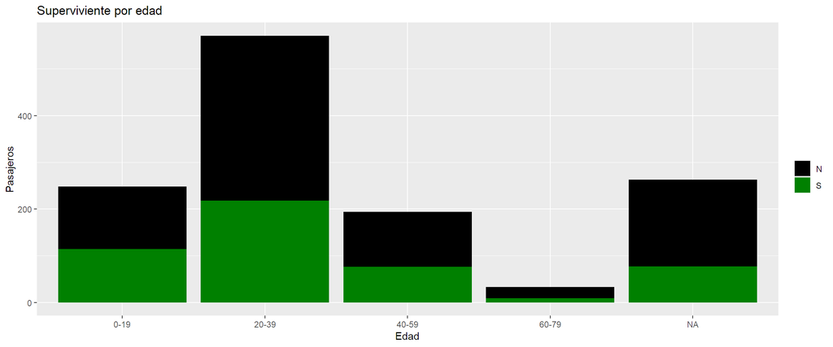

```r
ggplot(data,aes(Age,fill=Survived))+geom_bar() +labs(x="Edad", y="Pasajeros")+ guides(fill=guide_legend(title=""))+ scale_fill_manual(values=c("black","#008000"))+ggtitle("Superviviente por edad")
```

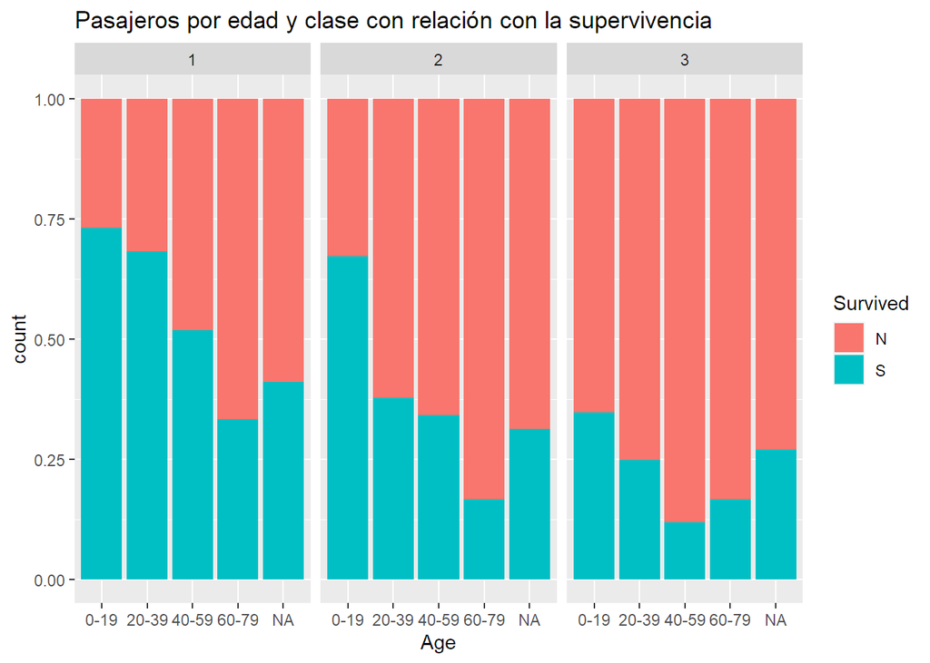

```r
ggplot(data,aes(x=Age,fill=Survived))+geom_bar(position="fill")+facet_wrap(~Pclass)+ggtitle("Pasajeros por edad y clase con relación con la supervivencia")
```

```r
tablaAge <- table(Age, Survived)
tablaAge
```

```
##       Survived
## Age     0  1
##   0.42  0  1
##   0.67  0  1
##   0.75  0  2
##   0.83  0  2
##   0.92  0  1
##   1     2  5
##   2     7  3
##   3     1  5
##   4     3  7
##   5     0  4
##   6     1  2
##   7     2  1
##   8     2  2
```

[output cut: 75 more lines]

```r
prop.table(tablaAge, margin = 1)
```

```
##       Survived
## Age            0         1
##   0.42 0.0000000 1.0000000
##   0.67 0.0000000 1.0000000
##   0.75 0.0000000 1.0000000
##   0.83 0.0000000 1.0000000
##   0.92 0.0000000 1.0000000
##   1    0.2857143 0.7142857
##   2    0.7000000 0.3000000
##   3    0.1666667 0.8333333
##   4    0.3000000 0.7000000
##   5    0.0000000 1.0000000
##   6    0.3333333 0.6666667
##   7    0.6666667 0.3333333
##   8    0.5000000 0.5000000
```

[output cut: 75 more lines]

### Sex

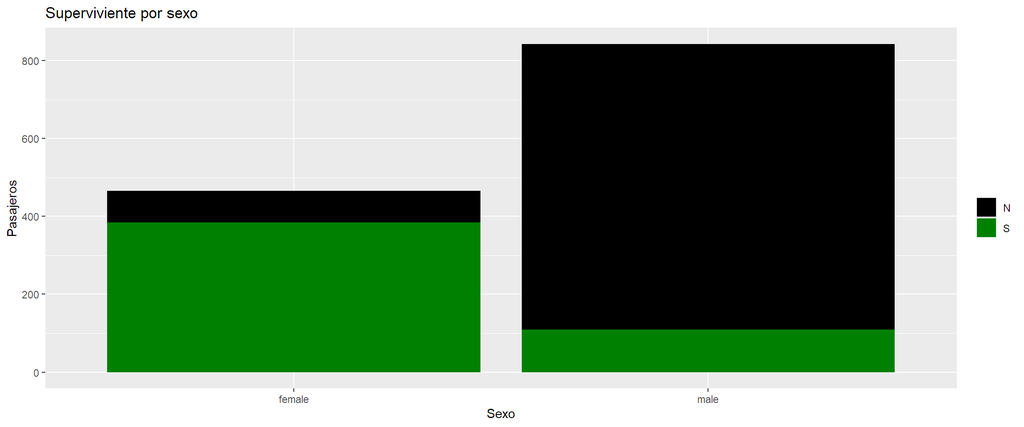

```r
ggplot(data,aes(Sex,fill=Survived))+geom_bar() +labs(x="Sexo", y="Pasajeros")+ guides(fill=guide_legend(title=""))+ scale_fill_manual(values=c("black","#008000"))+ggtitle("Superviviente por sexo")
```

```r
tablaSex <- table(Sex, Survived)
tablaSex
```

```
##         Survived
## Sex        0   1
##   female  81 233
##   male   468 109
```

```r
prop.table(tablaSex, margin = 1)
```

```
##         Survived
## Sex              0         1
##   female 0.2579618 0.7420382
##   male   0.8110919 0.1889081
```

## Correlación de variables

## Test estadísticos de significancia

**nota:** `para revisar`

Los resultados anteriores muestran los datos de forma descriptiva, podemos añadir algún test estadístico para validar el grado de significancia de la relación. La librería “DescTools” nos permite instalarlo fácilmente.

```r
if(!require(DescTools)){
    install.packages('DescTools', repos='http://cran.us.r-project.org')
    library(DescTools)
}
Phi(tablaClass)
```

```
## [1] 0.3398174
```

```r
CramerV(tablaClass)
```

```
## [1] 0.3398174
```

```r
Phi(tablaSex)
```

```
## [1] 0.5433514
```

```r
CramerV(tablaSex)
```

```
## [1] 0.5433514
```

```r
Phi(tablaAge)
```

```
## [1] 0.3819382
```

```r
CramerV(tablaAge)
```

```
## [1] 0.3819382
```

Una alternativa interesante a las barras de diagramas, es el plot de las tablas de contingencia. Obtenemos la misma información pero para algunos receptores puede resultar más visual.

[figure not shown]

```r
par(mfrow=c(2,2))
plot(tablaClass, col = c("black","#008000"), main = "SURVIVED vs. CLASS")
plot(tablaAge, col = c("black","#008000"), main = "SURVIVED vs. AGE")
plot(tablaSex, col = c("black","#008000"), main = "SURVIVED vs. SEX")
```